# RestHabitsMD

Stella & Lauren

11/16/2021

### BEGIN PROJECT

**load packages**

```r
library(tidyverse)
```

```r
library(knitr)
library(ggmosaic)
```

**reading in data**

```r
rest_habits_raw <- readr::read_csv(here::here("data","412MockData.csv"))
```

### CLEAN DATA

**Goals:**

- delete the extra columns
- do we need to rename?
- check for missing/incorrect values (what do we do?)

Rundown of variables:

[output not shown]

[output not shown]

|`sleepDuration` | duration slept each night |`sleepEnough` | is sleepDuration enough? (Y/N)

|`regSleep` | do they have a regular sleep schedule? (Y/N) |`sleepCatchUp` | “catch-up” on sleep? (Y/N) |`allNighter` | pull all nighers? |`dayTired` | feel tired during the day?

|`fallStayAsleep` | have issues falling/staying asleep? |`sleepDisorder` | previously diagnosed with a sleep disorder?

|`napFreq` | how frequently do they nap? |`napDuration` | how long are the naps?

|`leisureTime` | have leisure time? |`leisureFreq` | how much leisure time?

|`socialMedia` | do they use social media? |`socMedDuration` | how much time do they spend on social media?

|`academic_1` (academics) | how do they feel they are doing academically? |`mentalHealth_1` (energy) | energy levels |`mentalHealth_2` (stress) | stress levels |`mentalHealth_3` (concentration)| ability to concentrate |`mentalHealth_4` (mood) | overall mood

**TO DO** how to deal with undergrad? groups?

- delete unwanted cols/rows

```r
rest_habits <- rest_habits_raw %>%
  select(age:`mentalHealth _4`)
```

**TO DO** remove blank observations

```r
rest_habits <- rest_habits [-c(1),]
```

- renaming

```r
rest_habits <- rest_habits %>%
  rename(gpa=`gpa _1`,
         academics=`academic _1`,
         energy=`mentalHealth _1`,
         stress=`mentalHealth _2`,
         concentration=`mentalHealth _3`,
         mood=`mentalHealth _4`)
```

- convert age & gpa to numeric

```r
rest_habits$gpa <- as.numeric(rest_habits$gpa)
rest_habits$age <- as.numeric(rest_habits$age)
```

*writing out cleaned dataset for shiny app*

```r
readr::write_rds(rest_habits, here::here("RestHabits", "shinydata.rds"))
```

### MESSING WITH VISUALIZATIONS

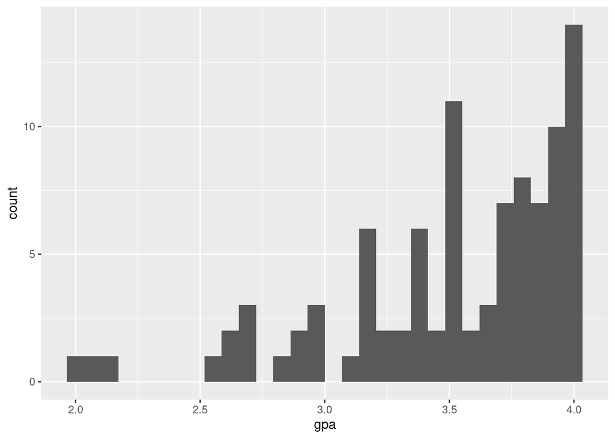

```r
rest_habits %>%
  ggplot() +
  geom_histogram(mapping = aes(x = gpa))
```

**TO DO** what vars do we want 4 realsies?

```r
c_table <-
  rest_habits %>%
  group_by(sex, sleepDisorder) %>%
  tally() %>%
  spread(key = sleepDisorder, value = n)

print.data.frame(c_table)
```

```
##      sex No Yes <NA>
## 1 Female 38   4   27
## 2   Male 14   3   20
```

(trying contingency table but *kable*)

```r
rest_habits %>%
  group_by(sex, sleepDisorder) %>%
  summarize(n=n()) %>%
  spread(sleepDisorder, n)%>%
  kable()
```

| sex | No | Yes |  |
| --- | --- | --- | --- |
| Female | 38 | 4 | 27 |
| Male | 14 | 3 | 20 |

**TO DO** remove n/a

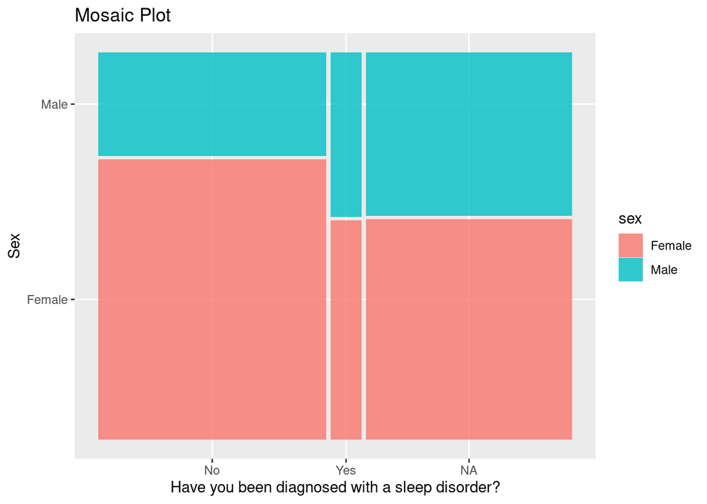

```r
rest_habits %>%
  ggplot() +
  geom_mosaic(aes(x=product(sex, sleepDisorder), fill=sex)) +
  labs(y="Sex", x="Have you been diagnosed with a sleep disorder?", title="Mosaic Plot")
```

- basic boxplot? even need or just stick to hist?

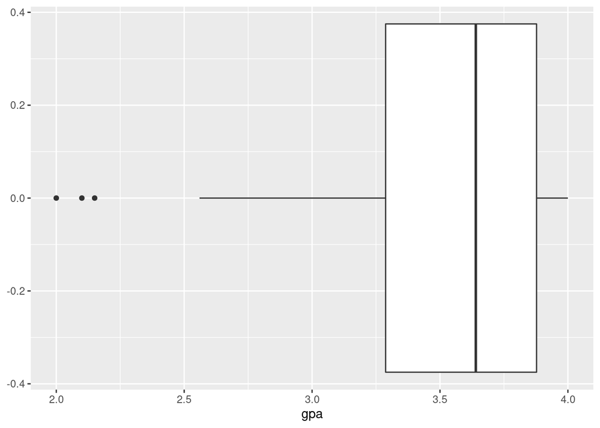

```r
ggplot(rest_habits, aes(x=gpa)) +
  geom_boxplot()
```

```r
ggplot(rest_habits, aes(x="", y=degree, fill=degree)) +
  geom_bar(stat="identity", width=1) +
  coord_polar("y", start=0) +
  theme_void()
```

[output not shown]

```r
rh <- rest_habits %>%
  filter(!is.na(grad))

ggplot(rh, aes(x="", y=grad, fill=grad)) +
  geom_bar(stat="identity", width=1) +
  coord_polar("y", start=0) +
  theme_void()
```

[output not shown]

(group undergrad majors by subject) **HOW**

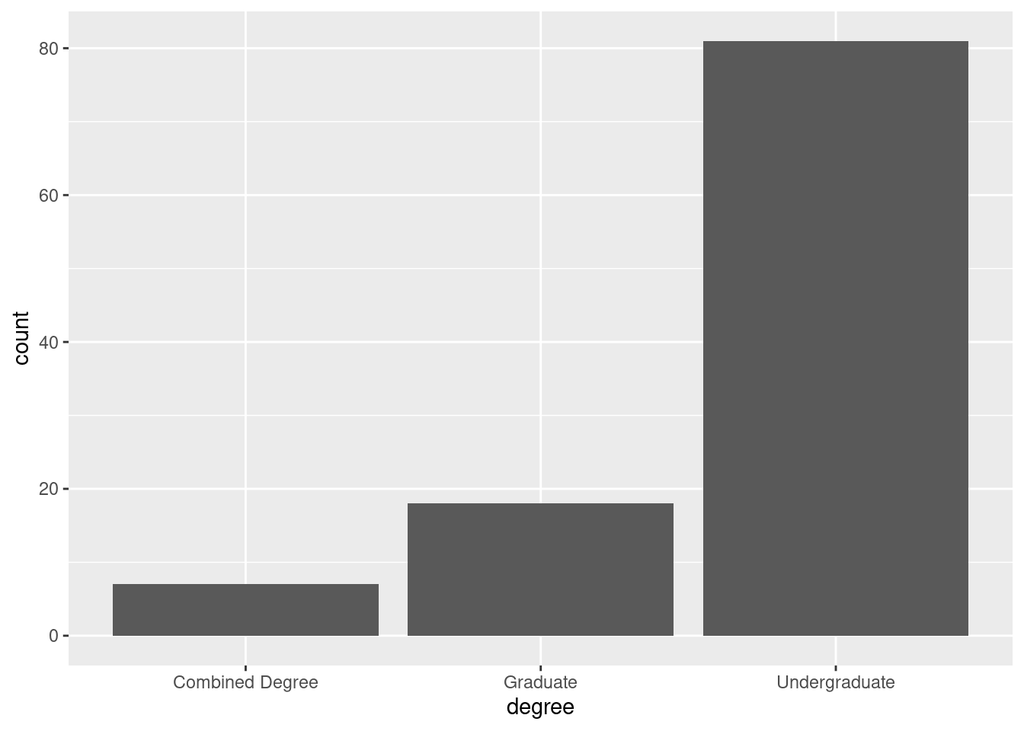

```r
ggplot(rest_habits, aes(x=degree)) +
  geom_bar()
```

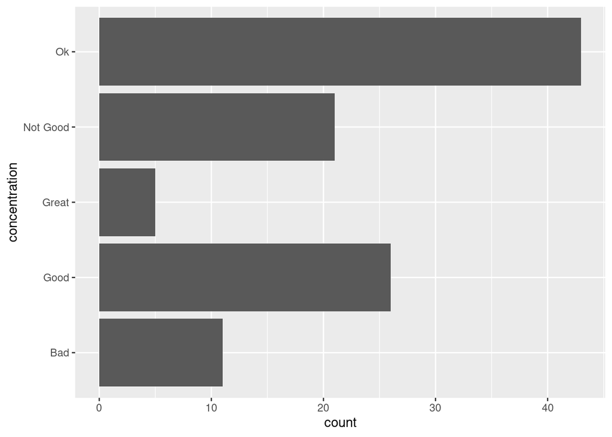

```r
ggplot(rest_habits, aes(x=concentration)) +
  geom_bar() +
  coord_flip()
```

### QUESTIONS I HAVE

- do particular degrees/majors sleep less than others?
- do those who sleep less have worse mental health/academics?
- do those who nap tend to have higher gpa/academic rating?
- do students think that the amount they sleep each night is enough?

### SOURCES

contingency tables: https://community.rstudio.com/t/how-do-you-convert-a-tidy-data-frame-to-a-contingency-table/99562/2

http://analyticswithr.com/contingencytables.html

box plots: http://www.sthda.com/english/wiki/ggplot2-box-plot-quick-start-guide-r-software-and-data-visualization

bar charts: http://www.sthda.com/english/wiki/ggplot2-barplots-quick-start-guide-r-software-and-data-visualization

mosaic plots: https://cran.r-project.org/web/packages/ggmosaic/vignettes/ggmosaic.html

pie chart: https://www.r-graph-gallery.com/piechart-ggplot2.html

circular bar plot: https://www.r-graph-gallery.com/web-circular-barplot-with-R-and-ggplot2.html looks cool af

analysis? https://scc.ms.unimelb.edu.au/resources-list/simple-r-scripts-for-analysis/r-scripts

### random shit

- change outlier, color, shape, size

ggplot(rest_habits, aes(x=*, y=*)) + geom_boxplot(outlier.colour=“red”, outlier.shape=8, outlier.size=4)

- change box plot line colors by groups

p <- ggplot(rest_habits, aes(x=*, y=*, color=***)) + geom_boxplot()

- use custom color palettes

p+scale_color_manual(values=c(“#999999”, “#E69F00”, “#56B4E9”))

- boxplot

bp + scale_fill_brewer(palette=“Dark2”)

- Scatter plot

sp + scale_color_brewer(palette=“Dark2”)

data <- tibble ( q1 = sample(n, c(…)) run simulations to make fake )